# Question 5: Finding a profitable app design

Austin Byrne

June 2023

### Abstract

The main aim of this analysis is to understand which apps perform the best by looking at the total installs, sentiment and average rating. From my analysis done it is evident that an app that focuses on communication and gaming will be best. In terms of paid vs free app sthere is not much difference in the rating therefore since free apps are more accessable by more people I would suggest creating a free communication or gaming app.

# Introduction

In this analysis I look at the total installs per category of app, the sentiment of each category and whther there is a difference in rating and sentiment for paid a free apps.

# 1 Data

## 1.1 Loading data

## 1.2 Creating a date column

## 1.3 Lets join the two datasets

# 2 Creating the plot

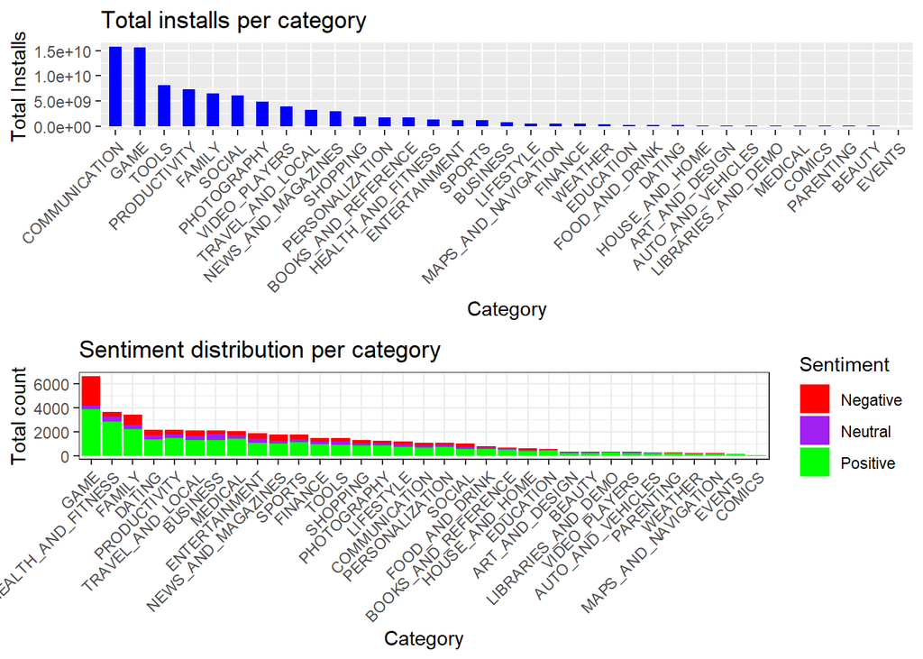

```
## function (bar_plot, sentiment_plot)
## {
##     combined_plot <- gridExtra::grid.arrange(bar_plot, sentiment_plot,
##         nrow = 2)
##     return(plots_combining_function)
## }
```

From the above plot it is evident that communication and gamming apps dominate the total installs. Although there will be a decent amount of competition there is a lot of growth opportunity for a pp that focuses on communication/gaming, possibly a market for joining the two categories.

# 3 Table for average rating free vs paid apps

Table 3.1: Sentiment polarity and ratings average pr free vs paid apps

| Type | Average Rating Average_Rating | Average Sentiment Polarity Average_Polarity |
| --- | --- | --- |
| Free | 4.273987 | 0.1790684 |
| Paid | 4.263024 | 0.2416216 |

# 4 Conclusion

Look into creating an app that focuses on communication due to the high installs ( This means there is a demand for these types of apps ). I would suggest communication over gaming as you are targeting a larger market and are less likely to be dominated by negative sentiment.